# Homework 1: Linear Regressions

STA 235H

Due on Sep. 8th, 11:59pm

# Note

- This document will serve as your Answer Key for Homework 1. Please check the rubric to understand how the assignment is graded.
- All automatically-graded questions will receive full credit if correct or 0 points if they are not correct. The only exception is with multiple answers were points are allocated proportionally (with discounts).
- Inconsistencies between code and answers will be discounted (i.e. if an answer is correct, but the code used to get to that answer is not, that question will be discounted).
- Any R scripts and PDF files will also be checked for completeness. If they are not complete (i.e. do not contain the code/output requested), a discount will apply.
- After you receive your graded assignment, you will have one week to submit re-grading requests. Please compare your graded submission with this answer key and fill out the re-grading form with your specific request.

# Introductory questions

In this task you will have to answer some short questions about interpretations of regressions and R output.

## Task 1 - Writing R code and understanding R output (15 points)

Question 1 to 5 are related to the following output. Smoker and Female are binary variables, and you can assume conventional units of measure for the other variables (dollars, years, etc.):

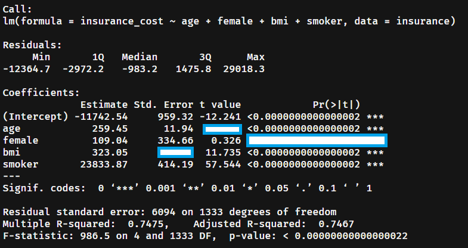

**1.1) What is the name of the dependent variable in the data?** *(2 points)*

*Answer:* `insurance_cost`

**1.2) What is the t-value that is missing in column (3) of the previous output?** *(2 points)*

*Answer: 21.7* ($=\frac{259.45}{11.94}$)

**1.3) Is the estimated coefficient for female statistically significant?** *(2 points)*

1. Yes, at 5% level
2. Yes, at 10% level
3. No
4. I don’t know

*Answer: No*

**1.4) What is the missing standard error?** *(2 points)*

*Answer: 27.53* ($=\frac{323.05}{11.735}$)

**1.5) Looking at the previous output, which of the following statements is/are TRUE** *(4 points)*

1. We can reject that the coefficient for smoker is equal to 0 (at <1% significance level).
2. The association between age and insurance costs is positive and statistically significant at conventional levels, holding other variables constant.
3. For a one unit increase in BMI (Body Mass Index), insurance cost increases on average by $323.
4. On average, a smoker pays almost $24,000 more in insurance than a non-smoker.

Answer:

1. and b)

**1.6) We want to fit the following model:**
$$GPA = \beta_0 + \beta_1HoursStudy +
\beta_2Attendance + \beta_3Attendance \times HoursStudy +
\varepsilon$$

**In order to do so, we have a dataset `D` with all the variables in our model. Complete the following line of code:** *(3 points)*

Answer: `lm(GPA ~ Attendance*HoursStudy, data = D)`

# The Economic Guide to Picking a College Major

FiveThirtyEight published a few years ago a post about college degrees and majors and their economic return. For the following tasks, we will be using their data (compiled from the American Community Survey) to do some analysis and dig a bit deeper into the economic success of college majors.

The data we will use can be found here, where each row represents a different major:

```r
grad = read.csv("https://raw.githubusercontent.com/maibennett/sta235/main/exampleSite/content/Assignments/Homework/Homework1/data/college_grads.csv")
```

You can see the codebook for this dataset [here](https://sta235.com/college_grads_codebook). We will first start with some data wrangling and data inspection, and then move to some analysis.

## Task 2 - Data Inspection (25 points)

**2.1) How many observations and variables are there in this dataset?** *(2 points)*

*Answer: 173 observations and 20 variables*

**2.2) How many different major categories are there? Include the code you use for this here.** *(3 points)*

*Answer: 16 categories*

```r
# You can create a table of the different majors and count them
grad %>% select(Major_category) %>% table()

# OR

# You can save that table in a new object
tab_categories = grad %>% select(Major_category) %>% table()

# Calculate the length of that table
length(tab_categories)
```

2 points for correct code

1 points for correct number

**2.3) On the same dataset, create a new variable called `ShareWomen` that captures the proportion (from 0 to 1) of female students in a major. Also, transform the variables `Total`, `Women`, and `Men`, into hundreds of graduates (instead of graduates). Share your code here.** *(4 points)*

*Answer:*

```r
grad = grad %>% mutate(ShareWomen = Women/Total,
                       Women = Women/100,
                       Men = Men/100,
                       Total = Total/100)
```

1 point per correct variable (4 max)

–1 point if names of variables is not correct/created a new dataset

**2.4) Which of the following statements is/are TRUE? Select all that apply.** *(5 points)*

1. All variables, with the exception of two, are numeric variables.
2. The average of low wage jobs in our data is 13,284.
3. There are no majors with 0 employed graduates.
4. The maximum median earnings for a major in our data is over $100,000.
5. The major with the highest share of women is in the education category.

*Answer: a), d), e)*

**2.5) Looking at the different categories of majors, what is the average percent of women in Biology & Life Science? What is the average proportion of women in Engineering?** *Note: Give your answer in % (0-100). Use 1 decimal place for your answer.* *(5 points)*

*Answer:*

```r
# Share of women in Biology and Life Science
grad %>% filter(Major_category=="Biology & Life Science") %>% select(ShareWomen) %>% summarize(avg_ShareWomen = mean(ShareWomen))

# Share of Women in Engineering
grad %>% filter(Major_category=="Engineering") %>% select(ShareWomen) %>% summarize(avg_ShareWomen = mean(ShareWomen))
```

On average, there is a share of 58.7% of women in Biology and Life Science majors, while there is an average of 23.9% of women in Engineering majors.

**2.6) Create a scatter plot between the proportion of women per major (x axis) and the median earnings for full-time workers. Briefly describe the plot.** *Note: Remember that your plot needs to be informative. Be aware of axis titles/labels.* *(6 points)*

*Answer:*

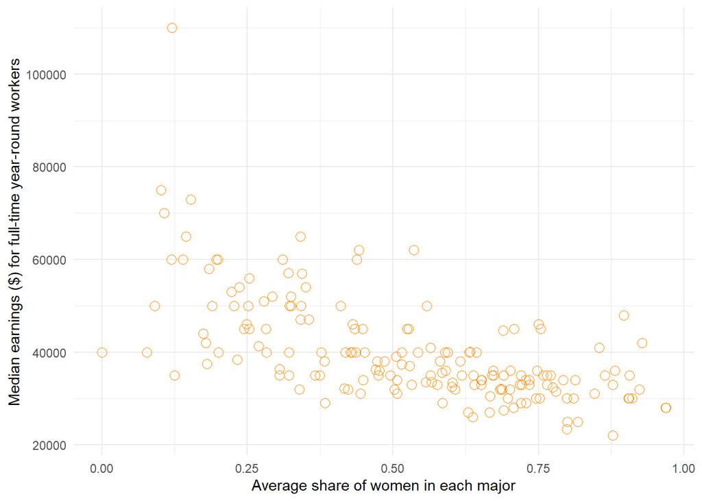

```r
ggplot(data = grad, aes(x = ShareWomen, y = Median)) +
  geom_point(pch = 21, color = "darkorange", size = 3) +
  xlab("Average share of women in each major") + ylab("Median earnings ($) for full-time year-round workers") +
  theme_minimal()
```

*We can see a negative association between median earnings and the share of women in each major. The negative association seems to be steeper for the 0-50% segment of proportion of women in a major.*

3 points for creating a scatter plot between `ShareWomen` (X) and `Median` (Y)

1 point for using appropriate axis labels

2 points for correct description of the plot (similar)

## Task 3 - Understanding earnings (40 points)

**3.1a) We want to better understand which variables are associated with median earnings. For this, we want to use as covariates the total number of people with a major, total number of women with a major, the proportion of graduates with a job that requires a college degree (`ShareCollegeJob`), and whether the major belongs to a the Computer & Math or Engineering category (`MathMajor`), which are majors that are math-focused. Create the missing covariates and include your code here.** *Note: Majors in the following categories are considered in “Math-oriented”.* *(4 points)*

```r
math_majors = c("Computers & Mathematics", "Engineering")
```

*Answer:*

```r
grad = grad %>% mutate(ShareCollegeJob = (College_jobs/100)/Total,
                       MathMajor = ifelse(Major_category %in% math_majors, 1, 0))

grad %>% select(MathMajor) %>% table()
```

```
## MathMajor
##   0   1
## 133  40
```

2 points for correct code for `MathMajor`

2 points for correct code for `ShareCollegeJob`

–1 point if `ShareCollegeJob` doesn’t take into account that `Total` is divided by 100.

**3.1b) How many majors are there in the “Math Major” category previously described?** *(1 point)*

*Of the 173 majors in our data, 40 are considered Math-focused majors.*

**3.2) Run a regression of median earnings on the covariates described in the previous question (question 6). Interpret the intercept.** *(5 points)*

*Answer:*

```r
lm_earn = lm(Median ~ Total + Women + ShareCollegeJob + MathMajor, data = grad)

summary(lm_earn)
```

```
##
## Call:
## lm(formula = Median ~ Total + Women + ShareCollegeJob + MathMajor,
##     data = grad)
##
## Residuals:
##    Min     1Q Median     3Q    Max
## -16557  -5048  -1222   3875  55949
##
## Coefficients:
##                  Estimate Std. Error t value             Pr(>|t|)
## (Intercept)     33843.964   1743.868  19.407 < 0.0000000000000002 ***
## Total               6.692      3.425   1.954               0.0524 .
## Women             -10.968      5.349  -2.050               0.0419 *
## ShareCollegeJob  7060.149   4562.806   1.547               0.1237
## MathMajor       15451.310   1814.862   8.514  0.00000000000000935 ***
## ---
## Signif. codes:  0 '***' 0.001 '**' 0.01 '*' 0.05 '.' 0.1 ' ' 1
##
## Residual standard error: 8777 on 167 degrees of freedom
##   (1 observation deleted due to missingness)
## Multiple R-squared:  0.4273, Adjusted R-squared:  0.4136
## F-statistic: 31.15 on 4 and 167 DF,  p-value: < 0.00000000000000022
```

*According to our model, a major that is not math-focused, that has 0 total graduates and 0 women, and where 0% of their graduates hold jobs that require college has an average median earning of $33,844. This intercept has no practical interpretation.*

1 point for correct estimate ($33,844)

1 point for “average”

3 points for covariates = 0 (need to explain what x=0 means in this context)

–2 points if it doesn’t explain what x=0 is

**3.3) Using the same model as before, interpret the coefficient for `MathMajor`.** *(5 points)*

*Answer: On average, the median earning of a Computer & Math or Engineering major is $15,451 more than a major that is not math-focused, holding number of total graduates, number of female graduates, and share of jobs requiring a college degree constant.*

1 point for correct estimate ($15,451) (If previous estimate was not correct, don’t discount again)

1 point for “average”

1 point for saying “math-focused majors **compared to** non math-focused majors” (or similar)

2 points for “holding other variables constant”

**3.4) We want to test the hypothesis that math-focused majors have a weaker association (i.e. smaller in magnitude) between number of women and earnings compared to non math-focused majors. Using the all the covariates used in the previous model, what model could we fit to test this hypothesis? Run the appropriate regression.** *(5 points)*

*Answer:*

```r
lm_math = lm(Median ~ ShareCollegeJob + Total + Women*MathMajor, data = grad)

summary(lm_math)
```

```
##
## Call:
## lm(formula = Median ~ ShareCollegeJob + Total + Women * MathMajor,
##     data = grad)
##
## Residuals:
##    Min     1Q Median     3Q    Max
## -16378  -4994  -1068   4246  54051
##
## Coefficients:
##                  Estimate Std. Error t value             Pr(>|t|)
## (Intercept)     33285.985   1752.895  18.989 < 0.0000000000000002 ***
## ShareCollegeJob  8224.798   4564.170   1.802               0.0734 .
## Total               9.302      3.651   2.548               0.0117 *
## Women             -14.513      5.608  -2.588               0.0105 *
## MathMajor       17199.089   2010.474   8.555  0.00000000000000753 ***
## Women:MathMajor   -37.887     19.421  -1.951               0.0528 .
## ---
## Signif. codes:  0 '***' 0.001 '**' 0.01 '*' 0.05 '.' 0.1 ' ' 1
##
## Residual standard error: 8704 on 166 degrees of freedom
##   (1 observation deleted due to missingness)
## Multiple R-squared:  0.4401, Adjusted R-squared:  0.4232
## F-statistic:  26.1 on 5 and 166 DF,  p-value: < 0.00000000000000022
```

5 points: Correct code, with all necessary covariates, and using `grad` (original dataset) as the data.

4 points: Same as above, but creates a new dataset (not `grad`)

3 points: Correct code, but doesn’t include `ShareCollegeJob` or `Total` as covariates.

0 points: Any other case

**3.5) Looking at the results for the prior model, which of the following statements is/are TRUE?** *(5 points)*

1. Our hypothesis is true because the association between number of women and median earnings is weaker (smaller in magnitude) for math-focused majors compared to non math-focused majors, holding other variables constant.
2. Our hypothesis is false because the association between number of women and median earnings is stronger (larger in magnitude) for math-focused majors compared to non math-focused majors, holding other variables constant and considering statistical significance at a 10% level.
3. We cannot know whether our hypothesis is true or not because the coefficient is not statistically significant at a 5% level.

*Answer:*

*b.*

**3.6) Using the previous model, interpret the association between the number of women in a major and median earnings for non math focused majors.** *(5 points)*

*Answer:*

*On average, holding share of college jobs and number of total graduates constant, for 100 additional women that graduate in a non math-focused major, the median earnings decrease by $14.5.*

1 point for correct estimate ($14.5) (If previous estimate was not correct, don’t discount again)

1 point for “average”

1 point for saying “for 100 additional women”

1 point for saying that this is for **non math-focused majors**

1 points for “holding other variables constant”

**3.7) Using the previous model, what is the association between the share of women in a major and median earnings for math focused majors?** *(5 points)*

*Answer:*

*-52.4*

**3.8) Assume we run the following regression:**
$$MedianEarnings = \beta_0 + \beta_1MathMajor +
\beta_2Women + \beta_3Women\times MathMajor + \varepsilon$$
**which of the following interpretations is correct for $\hat{\beta}_1$, assuming the coefficient is positive?***(5 points)*

*Answer:*

*On average, majors that are math-oriented have median earnings that are $ $\hat{\beta}_1$ higher that non math-oriented majors, when the number of women who graduate is 0*

## Task 4 - I just wanna be normal (20 points)

**4.1) Now, let’s look at our outcome, median earnings. Let’s create two histograms: 1) Histogram for the median earnings for full-time workers, and 2) Histogram of the logarithm of the median earnings for full-time workers. Include the figures here.** *Note: Use 25 bins for convenience.* *(6 points)*

*Answer:*

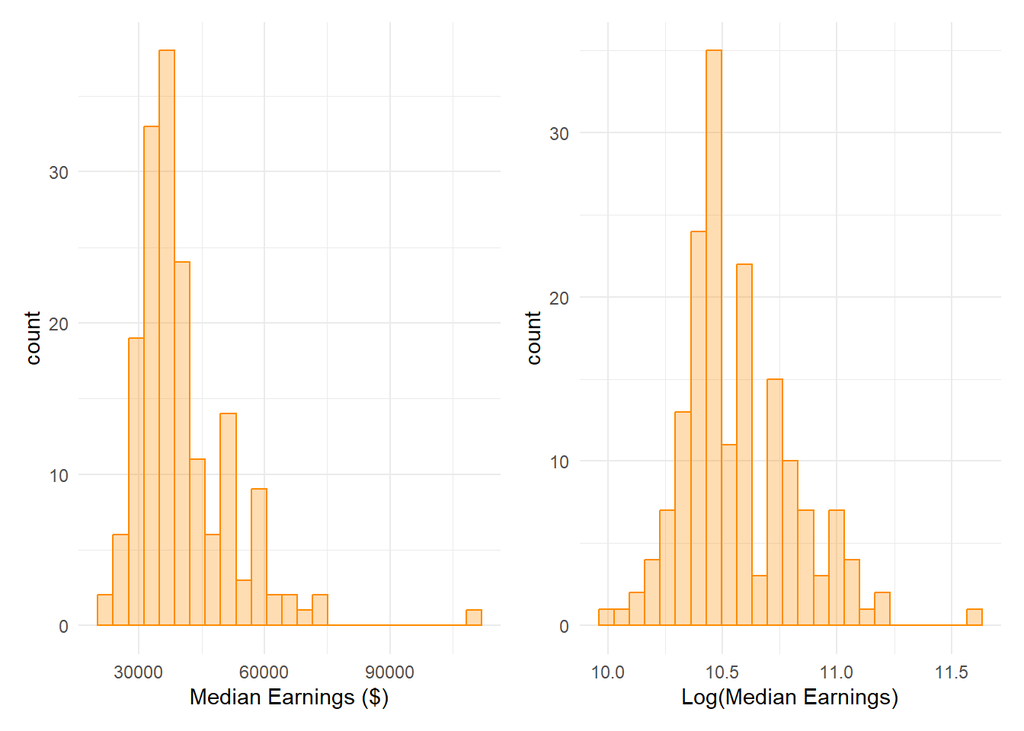

```r
library(patchwork)

g_earn = ggplot(grad, aes(x = Median)) +
  geom_histogram(bins = 25, color = "darkorange", fill = alpha("darkorange",0.3)) +
  xlab("Median Earnings ($)") +
  theme_minimal()

g_log = ggplot(grad, aes(x = log(Median))) +
  geom_histogram(bins = 25, color = "darkorange", fill = alpha("darkorange",0.3)) +
  xlab("Log(Median Earnings)") +
  theme_minimal()

g_earn + g_log
```

1 point (each) for using the right labels

1 point (each) for using the right number of bins

**4.2) Run a model that includes the total number of graduates, the share of jobs that require a college degree, whether a major is math-focused or not, the number of women who have that major, and the interaction between these last two covariates. Use $\log(Median)$ as your outcome. Interpret the coefficient for `Women`.** *Note: Interpretation should be related to earnings and **not** to logarithm of earnings*. *(8 points)*

*Answer:*

```r
lm_log_earn = lm(log(Median) ~ Total + ShareCollegeJob + MathMajor*Women, data = grad)

summary(lm_log_earn)
```

```
##
## Call:
## lm(formula = log(Median) ~ Total + ShareCollegeJob + MathMajor *
##     Women, data = grad)
##
## Residuals:
##      Min       1Q   Median       3Q      Max
## -0.46503 -0.12054 -0.02058  0.11097  0.71441
##
## Coefficients:
##                    Estimate  Std. Error t value             Pr(>|t|)
## (Intercept)     10.43257330  0.03796563 274.790 < 0.0000000000000002 ***
## Total            0.00022170  0.00007907   2.804              0.00565 **
## ShareCollegeJob  0.12240896  0.09885451   1.238              0.21736
## MathMajor        0.37867157  0.04354449   8.696  0.00000000000000321 ***
## Women           -0.00034111  0.00012146  -2.808              0.00558 **
## MathMajor:Women -0.00068162  0.00042064  -1.620              0.10704
## ---
## Signif. codes:  0 '***' 0.001 '**' 0.01 '*' 0.05 '.' 0.1 ' ' 1
##
## Residual standard error: 0.1885 on 166 degrees of freedom
##   (1 observation deleted due to missingness)
## Multiple R-squared:  0.4476, Adjusted R-squared:  0.431
## F-statistic:  26.9 on 5 and 166 DF,  p-value: < 0.00000000000000022
```

*On average, for a non math-focused major that graduate 100 additional women, median earnings decrease by 0.034%, holding number of total graduates, share of college jobs constant.*

2 points for correct estimate (0.034%)

3 point for saying that this is for **non math-focused majors**

1 point for “average median earning”

1 point for saying “for 100 additional women”

1 points for “holding other variables constant”

**4.3) What does the intercept represent in the previous model? Interpret that coefficient.** *(6 points)*

2 point for “average median earnings” or “average log(median earnings)”, depending on how they estimate this

3 points for covariates = 0 (need to explain what x=0 means in this context)

–2 points if it doesn’t explain what x=0 is